# Assignment-5

Asher John

11/24/2021

```r
library(tidyverse)
library(cluster)
library(factoextra)
library(dendextend)
library(dplyr)
set.seed(123)

df <- read.csv("Cereals.csv")

complete.cases(df)
```

```
##  [1]  TRUE  TRUE  TRUE  TRUE FALSE  TRUE  TRUE  TRUE  TRUE  TRUE  TRUE  TRUE
## [13]  TRUE  TRUE  TRUE  TRUE  TRUE  TRUE  TRUE  TRUE FALSE  TRUE  TRUE  TRUE
## [25]  TRUE  TRUE  TRUE  TRUE  TRUE  TRUE  TRUE  TRUE  TRUE  TRUE  TRUE  TRUE
## [37]  TRUE  TRUE  TRUE  TRUE  TRUE  TRUE  TRUE  TRUE  TRUE  TRUE  TRUE  TRUE
## [49]  TRUE  TRUE  TRUE  TRUE  TRUE  TRUE  TRUE  TRUE  TRUE FALSE  TRUE  TRUE
## [61]  TRUE  TRUE  TRUE  TRUE  TRUE  TRUE  TRUE  TRUE  TRUE  TRUE  TRUE  TRUE
## [73]  TRUE  TRUE  TRUE  TRUE  TRUE
```

```r
df <- df[complete.cases(df), ]
```

#### Preparing Data

```r
row.names(df) <- df[,1]

df <- df[, -1]

df1 <- df[, -(1:2)]

df1 <- scale(df1)
```

#### Single linkage method

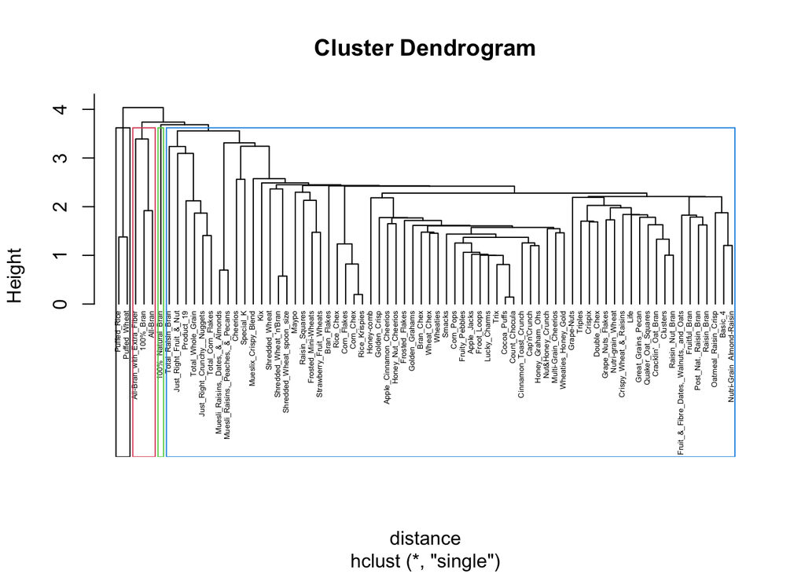

```r
distance <- dist(df1, method = "euclidean")

hc1 <- hclust(distance, method = "single")

plot(hc1, cex = 0.4, hang = -1)

rect.hclust(hc1, k = 4, border = 1:8)
```

#### Complete linkage method

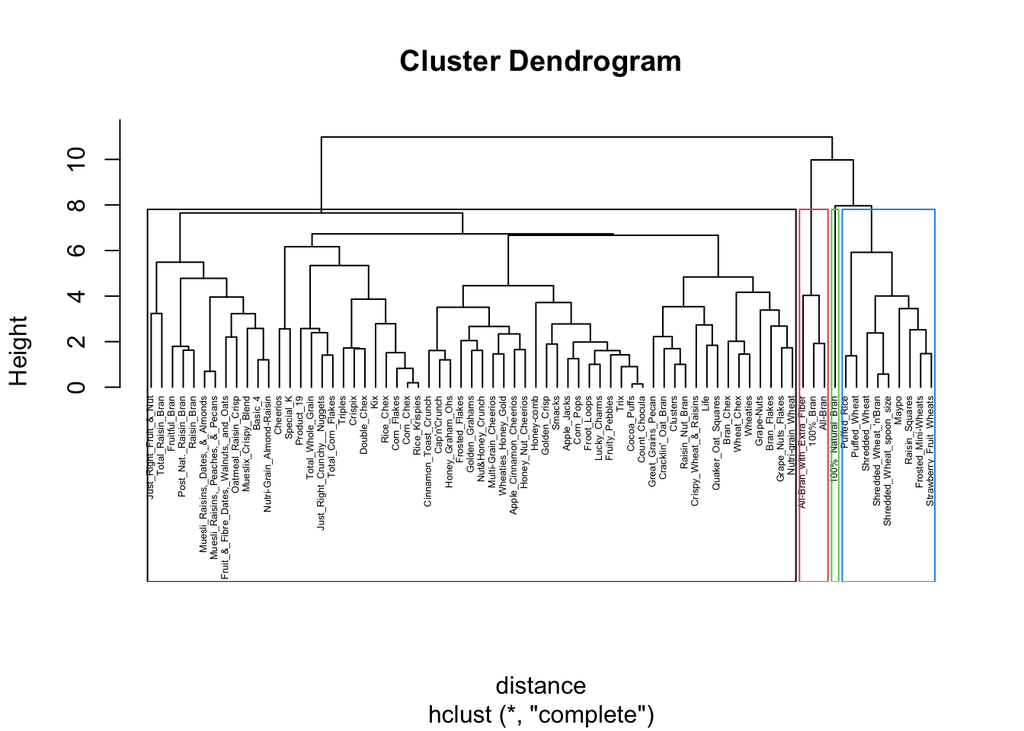

```r
hc2 <- hclust(distance, method = "complete")

plot(hc2, cex = 0.4, hang = -1)

rect.hclust(hc2, k = 4, border = 1:8)
```

#### Average linkage Method

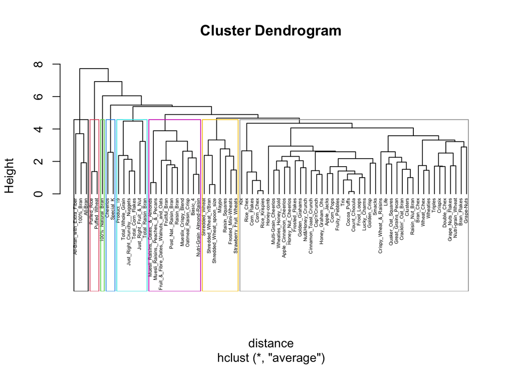

```r
hc3 <- hclust(distance, method = "average")

plot(hc3, cex = 0.4, hang = -1)

rect.hclust(hc3, k = 8, border = 1:8)
```

#### Ward.D method

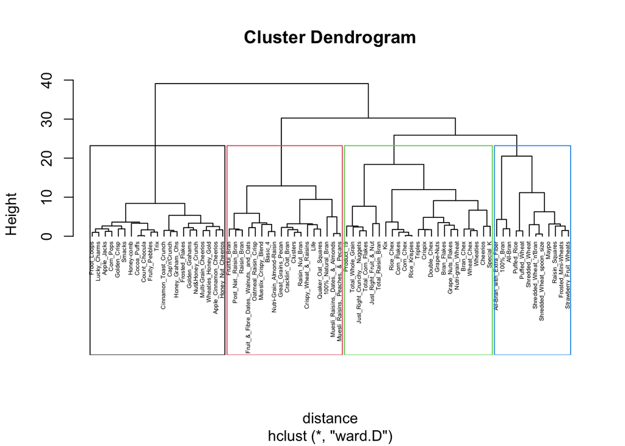

```r
hc4 <- hclust(distance, method = "ward.D")

plot(hc4, cex = 0.4, hang = -1)

rect.hclust(hc4, k = 4, border = 1:8)
```

```r
sub_grp <- cutree(hc4, k = 4)

table(sub_grp)
```

```
## sub_grp
##  1  2  3  4
## 12 18 21 23
```

```r
aggregate(df1, by = list(cluster = sub_grp), mean)
```

```
##   cluster     calories    protein        fat     sodium      fiber      carbo
## 1       1 -1.487965457  0.2972851 -0.7449152 -1.4129334  0.8903464 -0.4016428
## 2       2  0.765736610  0.6071316  1.0483992 -0.1225404  0.3860027 -0.3017144
## 3       3  0.197811688 -0.9199689  0.0000000  0.1210114 -0.6619844 -0.5423583
## 4       4 -0.003552997  0.2097198 -0.4318349  0.7225952 -0.1621971  0.9408738
##       sugars     potass   vitamins       shelf      weight       cups
## 1 -1.0188869  0.6617385 -0.6490756  0.04060222 -0.83636138 -0.3745547
## 2  0.4594980  0.7303221 -0.2441400  0.80843531  0.75879817 -0.6338128
## 3  0.9583619 -0.7415648 -0.1818422 -0.66046278 -0.20083243  0.2779676
## 4 -0.7030401 -0.2397304  0.6957441 -0.05084104  0.02588915  0.4376507
##       rating
## 1  1.6640733
## 2 -0.2475159
## 3 -0.9636465
## 4  0.2053471
```

```r
hc4_new <- cbind(df1, sub_grp)
```

### Clustering by AGNES

```r
library(cluster)
hc_single <- agnes(df1, method = "single")
hc_single$ac
```

```
## [1] 0.6067859
```

```r
hc_complete <- agnes(df1, method = "complete")
hc_complete$ac
```

```
## [1] 0.8353712
```

```r
hc_average <- agnes(df1, method = "average")
hc_average$ac
```

```
## [1] 0.7766075
```

```r
hc_ward <- agnes(df1, method = "ward")
hc_ward$ac
```

```
## [1] 0.9046042
```

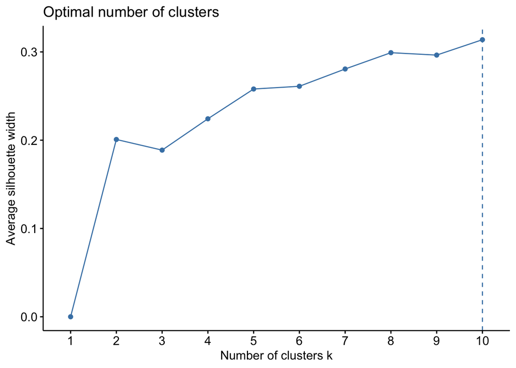

```r
fviz_nbclust(df1, FUN = hcut, method = "silhouette")
```

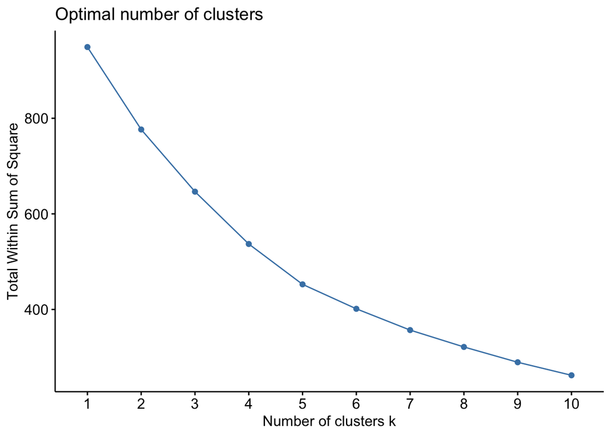

```r
fviz_nbclust(df1, FUN = hcut, method = "wss")
```

## Q.1

I will choose The “Ward” method as it shows the strongest clustering structure with a agglomerative coefficient of .904. it also makes my clusters more pronounced and distinct as compared to the other methods.

## Q. 2

I tried different ways (‘wss’ and ‘silhouette’) to pick the optimal number of clusters but I did not follow any of those recommendations. I will choose 4 clusters as it is a number that is not too big and not too small. If I pick a smaller number then clusters become too big. If I pick a bigger number than 4 then some clusters become too small and some become too big. Other reason for 4 is that this is the only number of clusters that shows a high variance between centroids of clusters. In my opinion 4 clusters are good as it divides the data in a way that distinctions between clusters are obvious and they are at a distance of around 22 from one an other.

## Q. 3

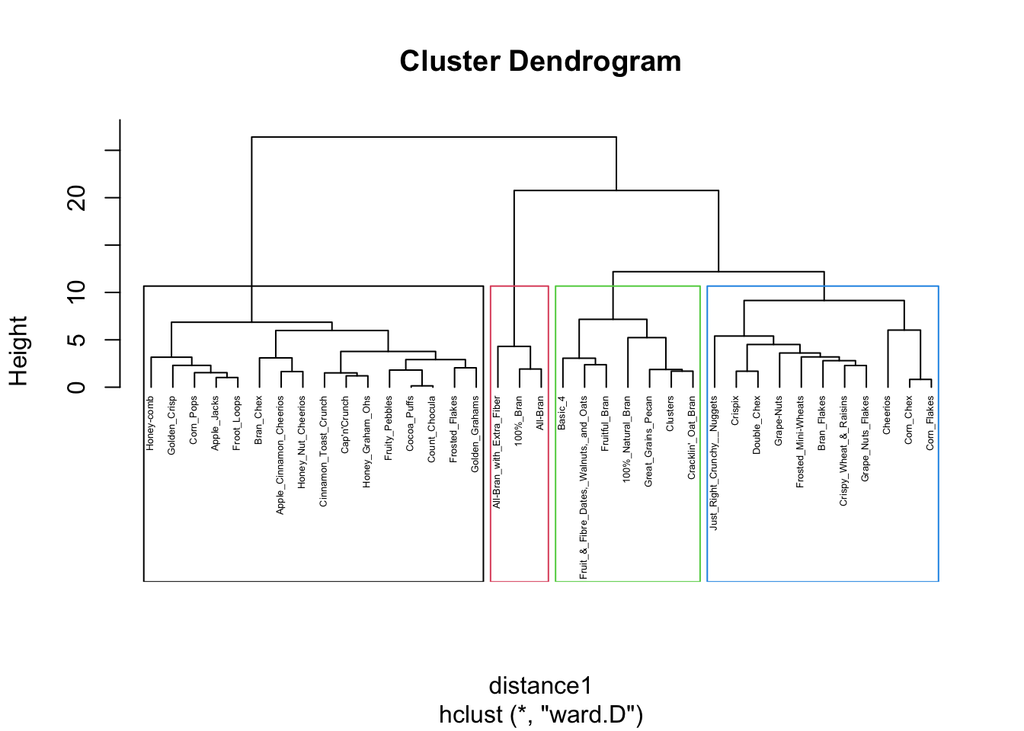

```r
## splitting the data

set.seed(13)

data.a <- df1[1:37, ]

data.b <- df1[38:74, ]

## finding the centroids for the partition A

distance1 <- dist(data.a, method = "euclidean")

hc5 <- hclust(distance1, method = "ward.D")

plot(hc5, cex = 0.4, hang = -1)

rect.hclust(hc5, k = 4, border = 1:4)
```

```r
sub_grp1 <- cutree(hc5, k = 4)

table(sub_grp1)
```

```
## sub_grp1
##  1  2  3  4
##  3  7 16 11
```

```r
centroid.a <- aggregate(data.a, by = list(cluster = sub_grp1), mean)

centroid.a
```

```
##   cluster   calories    protein        fat     sodium       fiber      carbo
## 1       1 -2.2018711  1.3817478 -0.3310734  0.1727901  3.64131237 -2.0718749
## 2       2  0.5817609  0.4522084  1.4188861 -0.2702057  0.45805176 -0.5545945
## 3       3  0.1498180 -1.0001970  0.0000000  0.1677561 -0.58829779 -0.5729487
## 4       4 -0.1708668  0.1986976 -0.5417565  0.3448629 -0.07249167  0.5600060
##       sugars     potass   vitamins      shelf     weight       cups     rating
## 1 -0.7894824  2.9837813 -0.1818422  0.9419715 -0.2008324 -1.8452553  2.2426479
## 2  0.2046041  0.6054720 -0.3420365  0.9419715  0.6465395 -0.8068760 -0.1729207
## 3  0.9645067 -0.7020942 -0.1818422 -0.7105388 -0.2008324  0.2609223 -0.9572966
## 4 -0.5878844 -0.2098960  0.1239833  0.1771733 -0.2008324  0.1203926  0.3434387
```

```r
## Assigning centroids from partition-A to partition-B of the original dataset.

assign <- data.frame(cer=seq(1,37,1), cluster=rep(0,37))

for (i in 1:37) {
  q <- as.data.frame(rbind(centroid.a[, -1], data.b[i, ]))
  m <- as.matrix(get_dist(q))
  assign[i, 2] <- which.min(m[4,-4])

}

rownames(assign) <- rownames(data.b)

head(table(assign))
```

```
##    cluster
## cer 3 4
##   1 1 0
##   2 1 0
##   3 0 1
##   4 1 0
##   5 1 0
##   6 1 0
```

```r
table(assign$cluster == df1[38:74,1])
```

```
##
## FALSE
##    37
```

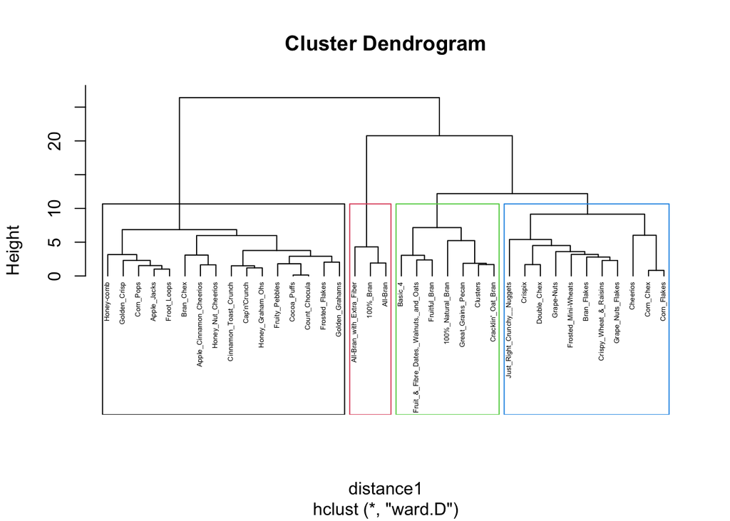

```r
## Comparing centroids in a more manual fashion

data.b <- df1[38:74, ]

distance2 <- dist(data.b, method = "euclidean")

hc6 <- hclust(distance1, method = "ward.D")

plot(hc6, cex = 0.4, hang = -1)

rect.hclust(hc6, k = 4, border = 1:4)
```

```r
sub_grp2 <- cutree(hc6, k = 4)

table(sub_grp2)
```

```
## sub_grp2
##  1  2  3  4
##  3  7 16 11
```

```r
aggregate(data.a, by = list(cluster = sub_grp2), mean)
```

```
##   cluster   calories    protein        fat     sodium       fiber      carbo
## 1       1 -2.2018711  1.3817478 -0.3310734  0.1727901  3.64131237 -2.0718749
## 2       2  0.5817609  0.4522084  1.4188861 -0.2702057  0.45805176 -0.5545945
## 3       3  0.1498180 -1.0001970  0.0000000  0.1677561 -0.58829779 -0.5729487
## 4       4 -0.1708668  0.1986976 -0.5417565  0.3448629 -0.07249167  0.5600060
##       sugars     potass   vitamins      shelf     weight       cups     rating
## 1 -0.7894824  2.9837813 -0.1818422  0.9419715 -0.2008324 -1.8452553  2.2426479
## 2  0.2046041  0.6054720 -0.3420365  0.9419715  0.6465395 -0.8068760 -0.1729207
## 3  0.9645067 -0.7020942 -0.1818422 -0.7105388 -0.2008324  0.2609223 -0.9572966
## 4 -0.5878844 -0.2098960  0.1239833  0.1771733 -0.2008324  0.1203926  0.3434387
```